# Lab 5

Abagail Ohmer

11/15/2021

## Background: FARS data

```r
library(ggplot2)
library(tidyverse)
library(lubridate)
acc <- read.csv("https://raw.githubusercontent.com/xdaiISU/ds202materials/master/hwlabs/fars2017/accident.csv", stringsAsFactors = FALSE)

per <- read.csv("https://raw.githubusercontent.com/xdaiISU/ds202materials/master/hwlabs/fars2017/person.csv", stringsAsFactors = FALSE)
```

## 1.

```r
fatal <- per %>% filter(INJ_SEV == 4)
head(fatal, 3)
```

```
##   STATE ST_CASE VE_FORMS VEH_NO PER_NO STR_VEH COUNTY DAY MONTH HOUR MINUTE
## 1     1   10001        1      1      1       0     73  19     2   23     35
## 2     1   10002        1      1      1       0     89  14     2   14     59
## 3     1   10003        3      2      1       0    101  31     1   20     31
##   RUR_URB FUNC_SYS HARM_EV MAN_COLL SCH_BUS MAKE MAK_MOD BODY_TYP MOD_YEAR
## 1       2        1      38        0       0   20   20421       15     2004
## 2       2        1       1        0       0   37   37402       14     2005
## 3       2        1      12        1       0    2    2404       14     2003
##   TOW_VEH SPEC_USE EMER_USE ROLLOVER IMPACT1 FIRE_EXP AGE SEX PER_TYP INJ_SEV
## 1       1        0        0        0      12        0  42   1       1       4
## 2       0        0        0        9       0        0  43   1       1       4
## 3       0        0        0        0       6        0  47   1       1       4
##   SEAT_POS REST_USE REST_MIS AIR_BAG EJECTION EJ_PATH EXTRICAT DRINKING ALC_DET
## 1       11       20        0       1        1       9        0        0       9
## 2       11        3        0       8        0       0        0        9       9
```

[output cut: 17 more lines]

## 2.

```r
danVeh <- fatal %>% filter(!(MAKE == "NA")) %>% group_by(STATE, MAKE) %>%  summarize(fatal = n()) %>% group_by(STATE) %>% filter(fatal == max(fatal))
head(danVeh, 10)
```

```
## # A tibble: 10 x 3
## # Groups:   STATE [9]
##    STATE  MAKE fatal
##    <int> <int> <int>
##  1     1    12   138
##  2     2    12     9
##  3     4    20    88
##  4     5    20    88
##  5     6    49   351
##  6     8    12    63
##  7     8    37    63
##  8     9    37    28
##  9    10    37    12
## 10    11    37     5
```

## 3.

The definition of the most dangerous vehicle is the type of vehicle with the most people who are fatally hurt in car accidents. From the graph we can see the regions of the US that have a certain type of car as the most dangerous. We can see overall, that Chevrolet have the most states with it as the dangerous vehicle.

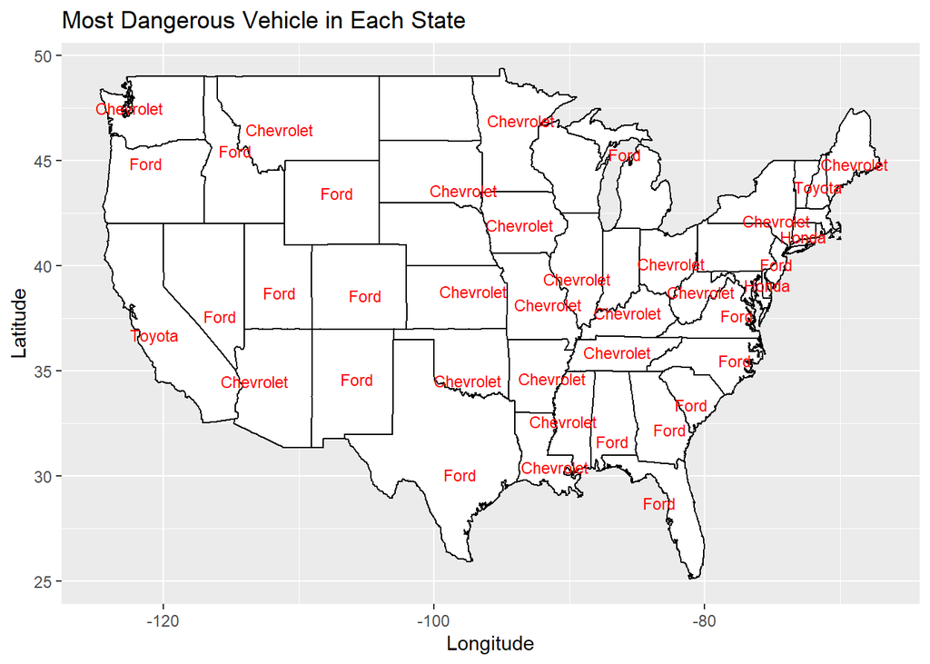

```r
GLC <- readxl::read_xlsx("GLC.xlsx")
GLC <- GLC %>% rename(NAME = `State Name`)
GLC <- GLC %>% rename(STATE = `State Code`)

GLC$STATE <- as.numeric(GLC$STATE)
GLC$NAME <- tolower(GLC$NAME)
GLC$'City Code' <- as.numeric(GLC$'City Code')
GLC$'County Code' <- as.numeric(GLC$'County Code')
danVeh$region <- tolower(danVeh$STATE)

USstate <- map_data('state')

name <- USstate %>% group_by(region) %>% summarize(long = mean(long, na.rm = TRUE), lat = mean(lat, na.rm = TRUE)) %>% left_join(GLC, by = c("region" = "NAME"))
name <- left_join(name, danVeh, by = "STATE")

name$MAKE <- factor(name$MAKE, levels = c(20, 12, 49, 37), labels = c("Chevrolet", "Ford", "Toyota", "Honda"))

ggplot(USstate, aes(x = long, y = lat)) + geom_polygon(aes(x = long, y = lat, group = group), color = 'black', fill = 'white') + geom_text(data = name, aes(long, lat, label = MAKE), color = 'red', size = 3, check_overlap = TRUE) + xlab("Longitude") + ylab("Latitude") + ggtitle("Most Dangerous Vehicle in Each State")
```

## 4.

```r
accPer <- acc %>% full_join(per, by = c("STATE", "ST_CASE", "VE_FORMS", "COUNTY", "DAY", "MONTH", "HOUR", "MINUTE", "RUR_URB", "FUNC_SYS", "HARM_EV", "MAN_COLL", "SCH_BUS"))

head(accPer, 3)
```

```
##   STATE ST_CASE VE_TOTAL VE_FORMS PVH_INVL PEDS PERNOTMVIT PERMVIT PERSONS
## 1     1   10001        1        1        0    0          0       1       1
## 2     1   10002        1        1        0    0          0       1       1
## 3     1   10003        3        3        0    0          0       3       3
##   COUNTY CITY DAY MONTH YEAR DAY_WEEK HOUR MINUTE NHS RUR_URB FUNC_SYS RD_OWNER
## 1     73  330  19     2 2017        1   23     35   1       2        1        1
## 2     89 1730  14     2 2017        3   14     59   1       2        1        1
## 3    101 2130  31     1 2017        3   20     31   1       2        1        1
##   ROUTE TWAY_ID       TWAY_ID2 MILEPT LATITUDE  LONGITUD SP_JUR HARM_EV
## 1     1   I-459                    10 33.33566 -87.00709      0      38
## 2     1   I-565                    70 34.66153 -86.78685      0       1
## 3     1    I-85 CHANTILLY PKWY    100 32.36652 -86.14528      0      12
##   MAN_COLL RELJCT1 RELJCT2 TYP_INT WRK_ZONE REL_ROAD LGT_COND WEATHER1 WEATHER2
## 1        0       0       1       1        0        3        2        1        0
## 2        0       0       1       1        0        3        1        1        0
```

[output cut: 33 more lines]

## 5.

From the graph, we can see that the most accidents for males happens on Friday at approx. 6pm, and for women, it is also on Friday at 6pm. The Least accidents for both males and females is on Tuesday.

```r
accPer <- accPer %>% filter((SEX == 1 || SEX == 2) && (HOUR < 25))

accPer$SEX <- factor(accPer$SEX, levels = c(1, 2), labels = c("Male", "Female"))
accPer$DAY_WEEK <- factor(accPer$DAY_WEEK, levels = c(1,2,3,4,5,6,7), labels = c("Sun", "Mon", "Tue", "Wed", "Thur", "Fri", "Sat"))


accPer %>% group_by(SEX, DAY_WEEK, HOUR) %>% summarise(count = n()) %>% group_by(SEX) %>% filter(count == max(count)) %>% arrange(desc(count))
```

```
## # A tibble: 3 x 4
## # Groups:   SEX [3]
##   SEX    DAY_WEEK  HOUR count
##   <fct>  <fct>    <int> <int>
## 1 Male   Fri         18   596
## 2 Female Fri         18   333
## 3 <NA>   Fri         21    37
```

```r
tally <- accPer %>% group_by(SEX, DAY_WEEK, HOUR) %>% summarise(count = n()) %>% filter(!(HOUR == 99)) %>% filter(!(SEX == 9))
```

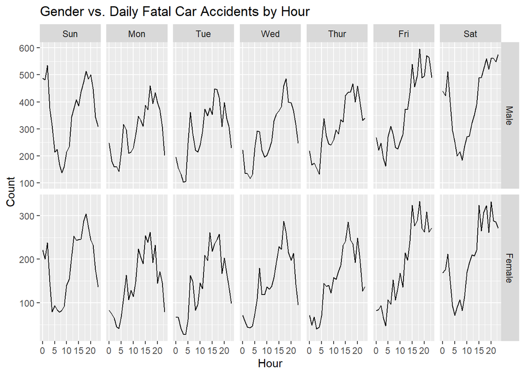

```r
ggplot(tally, aes(x = HOUR, y = count)) + geom_line() + facet_grid(SEX ~ DAY_WEEK, scales = 'free') + xlab("Hour") + ylab("Count") + ggtitle("Gender vs. Daily Fatal Car Accidents by Hour")
```

## 6.

```r
GLC <- GLC %>% rename(CNAME = "County Name")
GLC <- GLC %>% rename(COUNTY = "County Code")
GLC$COUNTY <- as.integer(GLC$COUNTY)

dead <- acc %>% select(c("STATE", "COUNTY", "FATALS")) %>%  group_by(STATE, COUNTY) %>% summarize(death = sum(FATALS))
```

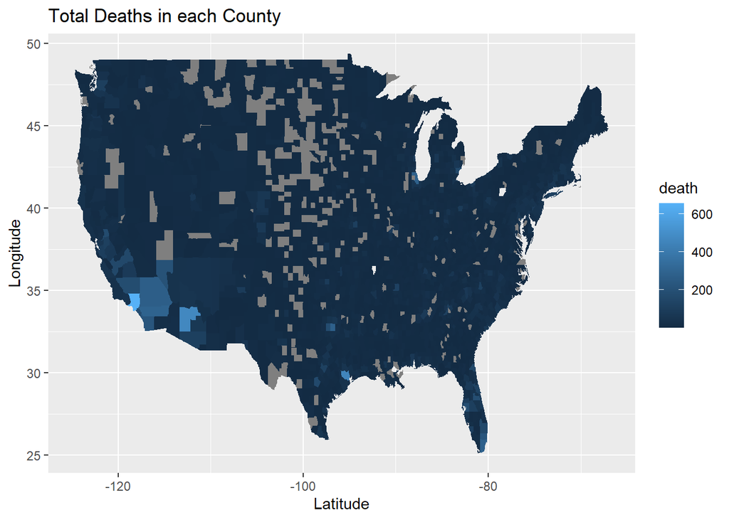

```r
dead <- dead %>% left_join(GLC, by = c('COUNTY', 'STATE'))
dead <- unique(dead[c('NAME', 'CNAME', 'death')])
dead$CNAME <- tolower(dead$CNAME)
map <- map_data('county')
dead <- dead %>% right_join(map, by = c(CNAME = 'subregion', NAME = 'region'))

dead %>% ggplot(aes(x = long, y = lat, group= group, fill = death)) + geom_polygon() + ggtitle("Total Deaths in each County") + xlab("Latitude") + ylab("Longitude")
```

## 7. Theory~

Summer would be June - Aug and Winter would be Dec - Feb. Use fatal and filter months into 2 variables based on winter or summer. group by the season. Follow similar steps as the previous state problem!